# Try

Jorge Cimentada

March 11, 2017

## Skeleton

**Rmarkdown Skeleton:**  
title: “Try”  
author: “Jorge Cimentada”  
date: “March 11, 2017”  
output: html_document  
bibliography: bibliography.bib  
params:  
start: !r Sys.Date()

## R markdown

When you open an Rmarkdown document, Rstudio writes the skeleton by default, but you can also add other options. Note that the `title`, `author` and `date` options are standard, regardless of the type of document.

We can specify the type of document we want with the `output` option. We can use `pdf_document`, `word_document`, among other things. See [here](http://rmarkdown.rstudio.com/formats.html) for all available formats. See how I created a link from that word? You can do that by wrapping the word with `[]` and placing the link wrapped in `()` next to it.

You can set a bibliography argument, if you created a .bib. file. What is a .bib file?. You can create these citations from Google Scholar automatically.

In short, the benefits of R markdown is that we can write code and text in the same document. I could, for example, explain something about how cars with 4 cylinders have greater miles per gallon than other cars and show this graph:

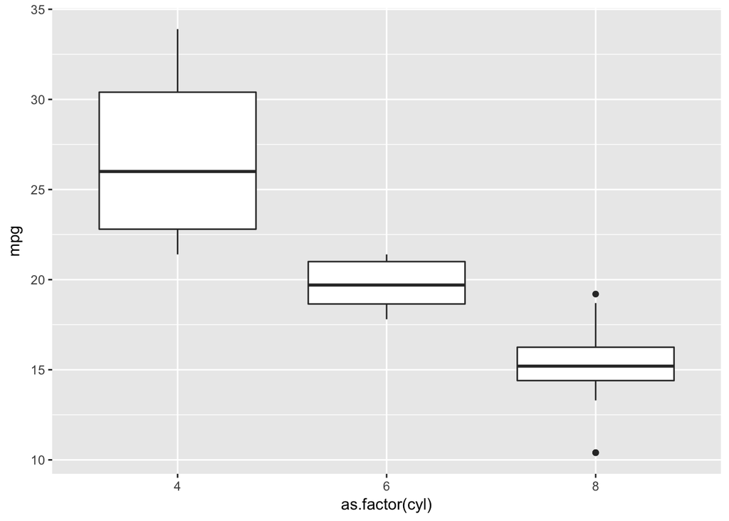

The cool thing about this is that we avoid pasting the plot to the document: we’re generating it everytime we run the R markdown file. Now, if you’re looking at the source code of the document, you’ll note that the code is wrapped in weird `tildes` and `{}`.

## Code chunks

In Rmarkdown everything that is surrounded by:

```{r}

```

is interpreted as code that needs to be executed. These are called `code chunks`. `Code chunks` have many options that allow you to customize how the chunk behaves. For example, in the previous example we produced a plot but we hid the code. We can make the code explicit by setting the `echo` function to `T` or simply deleting the `echo` options (because echo is set to `T` by default.)

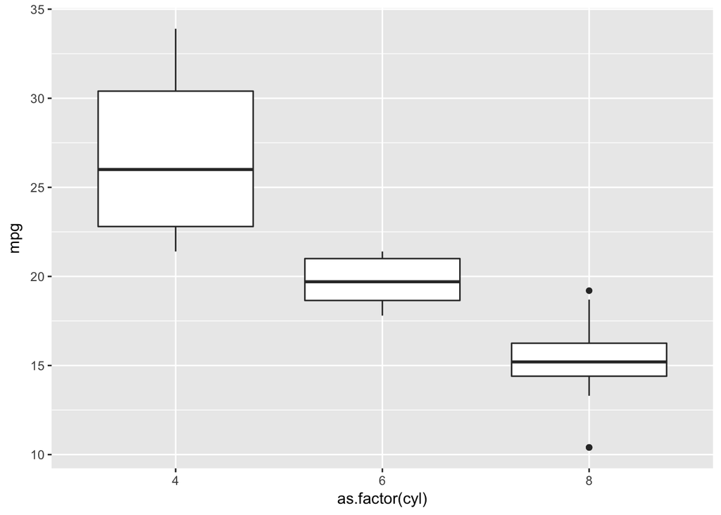

```r
library(tidyverse)

mtcars %>%
  ggplot(aes(as.factor(cyl), mpg)) +
  geom_boxplot()
```

We can also name chunks to give our code more structure. We place the name right after the `r` option in the `{}` Also note the `message` and `warning` options. As you might’ve thought, both these options print/supress messages and warnings (both things that actually happen when loading the `tidyverse`)

`Code chunks` have about 60 options for full customization. The most widely used options are:

- `eval = FALSE` prevents code from being evaluated.
- `include = FALSE` runs the code, but doesn’t show the code or results in the final document.
- `echo = FALSE` shows output but not the code.
- `message = FALSE` or `warning = FALSE` prevents messages or warnings from appearing in the finished file.
- `results = 'hide'` hides printed output; `fig.show = 'hide'` only hides plots.
- `error = TRUE` causes the render to continue even if code returns an error.
- `cache = T` When set, this will save the output of the chunk to a specially named file on disk. On subsequent runs, knitr will check to see if the code has changed, and if it hasn’t, it will reuse the cached results.

Here are some examples of all of these options:

`eval = F`: Code is not executed (but shown)

```r
mtcars %>%
  ggplot(aes(as.factor(cyl), mpg)) +
  geom_boxplot()
```

`include = F`: code gets executed but neither the code nor the output is shown.

```r
mtcars %>%
  group_by(cyl) %>%
  summarise(n = n())
```

`fig.show = 'hide'`: plots won’t be shown, but any other output will.

```r
mtcars %>%
  ggplot(aes(as.factor(cyl), mpg)) +
  geom_boxplot()
```

```r
mtcars %>%
  group_by(cyl) %>%
  summarise(n = n())
```

```
## # A tibble: 3 × 2
##     cyl     n
##   <dbl> <int>
## 1     4    11
## 2     6     7
## 3     8    14
```

`error = T`: code chunk will continue, even if there’s an error.

```r
log("not a number")
```

```
## Error in log("not a number"): non-numeric argument to mathematical function
```

```r
mtcars %>%
  group_by(cyl) %>%
  summarise(n = n())
```

```
## # A tibble: 3 × 2
##     cyl     n
##   <dbl> <int>
## 1     4    11
## 2     6     7
## 3     8    14
```

More importantly, `cache = T` will pre-load the code chunk.

```r
x <- rnorm(10^8)
```

This code takes a couple of seconds to execute. You can set ```{r} cache = T ```, so that after the code is executed once, everytime you rerun the Rmarkdown file Rmarkdown will load the file for this chunk and avoid rerunning it.

Each `code chunk` can fully customized with each of these options but it’s a bit of a hassle to specify the same option for all chunks (imagine you have 100 chunks). You can always set ‘global’ options that will be applied to each chunk. You can do that this way:

```r
knitr::opts_chunk$set(
  echo = F,
  message = F
  )
```

Knitr provides almost 60 options that you can use to customize your code chunks. You can see the full list at http://yihui.name/knitr/options/.

# Tables and paragraphs.

This is the first paragraph I’ll type. But to generate a second paragraph, the sentence needs to end with two additional spaces.

This is the second paragraph.

This is the third paragraph.

You can print tables or data frames just as they are. For example

```r
head(mtcars)
```

```
##                    mpg cyl disp  hp drat    wt  qsec vs am gear carb
## Mazda RX4         21.0   6  160 110 3.90 2.620 16.46  0  1    4    4
## Mazda RX4 Wag     21.0   6  160 110 3.90 2.875 17.02  0  1    4    4
## Datsun 710        22.8   4  108  93 3.85 2.320 18.61  1  1    4    1
## Hornet 4 Drive    21.4   6  258 110 3.08 3.215 19.44  1  0    3    1
## Hornet Sportabout 18.7   8  360 175 3.15 3.440 17.02  0  0    3    2
## Valiant           18.1   6  225 105 2.76 3.460 20.22  1  0    3    1
```

You can also use the `kable` function from the `knitr` package. For example:

```r
knitr::kable(head(mtcars))
```

|  | mpg | cyl | disp | hp | drat | wt | qsec | vs | am | gear | carb |
| --- | --- | --- | --- | --- | --- | --- | --- | --- | --- | --- | --- |
| Mazda RX4 | 21.0 | 6 | 160 | 110 | 3.90 | 2.620 | 16.46 | 0 | 1 | 4 | 4 |
| Mazda RX4 Wag | 21.0 | 6 | 160 | 110 | 3.90 | 2.875 | 17.02 | 0 | 1 | 4 | 4 |
| Datsun 710 | 22.8 | 4 | 108 | 93 | 3.85 | 2.320 | 18.61 | 1 | 1 | 4 | 1 |
| Hornet 4 Drive | 21.4 | 6 | 258 | 110 | 3.08 | 3.215 | 19.44 | 1 | 0 | 3 | 1 |
| Hornet Sportabout | 18.7 | 8 | 360 | 175 | 3.15 | 3.440 | 17.02 | 0 | 0 | 3 | 2 |
| Valiant | 18.1 | 6 | 225 | 105 | 2.76 | 3.460 | 20.22 | 1 | 0 | 3 | 1 |

You can also use the `stargazer` package for creating nicely formatted tables.

```r
# install.packages("stargazer") # In case you don't have it installed
library(stargazer)
stargazer(mtcars, type = "html")
```

| Statistic | N | Mean | St. Dev. | Min | Max |
| --- | --- | --- | --- | --- | --- |
| mpg | 32 | 20.091 | 6.027 | 10.400 | 33.900 |
| cyl | 32 | 6.188 | 1.786 | 4 | 8 |
| disp | 32 | 230.722 | 123.939 | 71.100 | 472.000 |
| hp | 32 | 146.688 | 68.563 | 52 | 335 |
| drat | 32 | 3.597 | 0.535 | 2.760 | 4.930 |
| wt | 32 | 3.217 | 0.978 | 1.513 | 5.424 |
| qsec | 32 | 17.849 | 1.787 | 14.500 | 22.900 |
| vs | 32 | 0.438 | 0.504 | 0 | 1 |
| am | 32 | 0.406 | 0.499 | 0 | 1 |
| gear | 32 | 3.688 | 0.738 | 3 | 5 |
| carb | 32 | 2.812 | 1.615 | 1 | 8 |

Also for regression models.

```r
mod1 <- lm(mpg ~ cyl, data = mtcars)
stargazer(mod1, type = "html")
```

|  | *Dependent variable:* |
| --- | --- |
|  | mpg |
| cyl | -2.876*** |
|  | (0.322) |
| Constant | 37.885*** |
|  | (2.074) |
| Observations | 32 |
| R<sup>2</sup> | 0.726 |
| Adjusted R<sup>2</sup> | 0.717 |
| Residual Std. Error | 3.206 (df = 30) |
| F Statistic | 79.561*** (df = 1; 30) |
| *Note:* | p<0.1; p<0.05; p<0.01 |

## Sourcing code

You might be writing code and text in the same document, but for some reason you want to extract all of the code without the text to have a separate code file. You can do that with the `purl` function. For example, since this document is called `fifth_seminar.Rmd`, you could open a new session and write:

```r
purl("directory_to_file/fifth_seminar.Rmd")
```

This will save a copy of an `.R` file with all the code from this document.

## Inline code

You can also use inline code. So let’s suppose you’re describing your data and you want to cite the dimensions and the mean of a column. Our `mtcars` data has 32 rows and 11. Those two numbers were actually calculated on the spot. If we updated the data, then the number gets updated. The mean of miles per gallon is 20.09. This also was calculated on the fly. With this option you can create report documents that get updated everytime you input new data. You can also perform any operation like 1 + 1 is 2.

## Other programming languages

R markdown has also the capacity to run other programming languages. It is very common for R users to be also proficient with `bash`, `python` or `stan`.